# Occupancy Detection Classification Project

## Goal

The goal of this project is to implement and compare three different classification algorithms—Random Forest, Support Vector Machine (SVM), and Long Short-Term Memory (LSTM)—to predict room occupancy based on environmental sensor data such as temperature, humidity, light, CO2, and humidity ratio. We will evaluate the performance of these models using 10-fold cross-validation and calculate various performance metrics manually.

## 1. Introduction

### 1.1 Dataset Description

**Dataset Name:** Occupancy Detection Data Set  
**Source:** UCI Machine Learning Repository  
**URL:** [Occupancy Detection Data Set](https://archive.ics.uci.edu/dataset/357/occupancy+detection)  
**Description:** The dataset contains experimental data used for binary classification (room occupancy) from temperature, humidity, light, and CO2 measurements. Ground-truth occupancy was obtained from time-stamped pictures taken every minute.

### 1.2 Features

- **date:** Date and time (year-month-day hour:minute:second)
- **Temperature:** Temperature in degrees Celsius
- **Humidity:** Relative humidity in %
- **Light:** Light intensity in Lux
- **CO2:** CO2 concentration in parts per million (ppm)
- **HumidityRatio:** Derived quantity from temperature and relative humidity
- **Occupancy:** Target variable (0 for unoccupied, 1 for occupied)

### 1.3 Objective

**Predict:** Whether a room is occupied or not based on sensor data.  
**Algorithms Used:**

- Random Forest
- Support Vector Machine (SVM)
- Long Short-Term Memory (LSTM)

**Evaluation Metrics:**

- True Positive (TP)
- True Negative (TN)
- False Positive (FP)
- False Negative (FN)
- True Positive Rate (TPR)
- True Negative Rate (TNR)
- False Positive Rate (FPR)
- False Negative Rate (FNR)
- Precision
- F1 Score
- Accuracy
- Error Rate
- Balanced Accuracy (BACC)
- True Skill Statistic (TSS)
- Heidke Skill Score (HSS)
- Area Under ROC Curve (AUC)
- Brier Score

## 2. Importing Libraries

```python
import numpy as np
import pandas as pd
import matplotlib.pyplot as plt
import seaborn as sns
import warnings
warnings.filterwarnings("ignore")

from sklearn.model_selection import KFold
from sklearn.metrics import confusion_matrix, roc_auc_score, roc_curve, auc, brier_score_loss
from sklearn.preprocessing import StandardScaler
from sklearn.svm import SVC
from sklearn.ensemble import RandomForestClassifier

from keras.models import Sequential
from keras.layers import Dense, LSTM
```

## 3. Loading and Preprocessing the Data

### 3.1 Loading the Dataset

```python
# Load the dataset
df = pd.read_excel('FinalDataset.xlsx')
```

### 3.2 Exploring the Dataset

```python
# Display the first few rows
df.head()
```

|  | date | Temperature | Humidity | Light | CO2 | HumidityRatio | Occupancy |
| --- | --- | --- | --- | --- | --- | --- | --- |
| 0 | 2015-02-02 14:19:00 | 23.7000 | 26.272 | 585.200000 | 749.200000 | 0.004764 | 1 |
| 1 | 2015-02-02 14:19:59 | 23.7180 | 26.290 | 578.400000 | 760.400000 | 0.004773 | 1 |
| 2 | 2015-02-02 14:21:00 | 23.7300 | 26.230 | 572.666667 | 769.666667 | 0.004765 | 1 |
| 3 | 2015-02-02 14:22:00 | 23.7225 | 26.125 | 493.750000 | 774.750000 | 0.004744 | 1 |
| 4 | 2015-02-02 14:23:00 | 23.7540 | 26.200 | 488.600000 | 779.000000 | 0.004767 | 1 |

```python
# Get dataset information
df.info()
```

```
<class 'pandas.core.frame.DataFrame'>
RangeIndex: 20560 entries, 0 to 20559
Data columns (total 7 columns):
 #   Column         Non-Null Count  Dtype
---  ------         --------------  -----
 0   date           20560 non-null  object
 1   Temperature    20560 non-null  float64
 2   Humidity       20560 non-null  float64
 3   Light          20560 non-null  float64
 4   CO2            20560 non-null  float64
 5   HumidityRatio  20560 non-null  float64
 6   Occupancy      20560 non-null  int64
dtypes: float64(5), int64(1), object(1)
memory usage: 1.1+ MB
```

```python
# Check for missing values
df.isnull().sum()
```

```
date             0
Temperature      0
Humidity         0
Light            0
CO2              0
HumidityRatio    0
Occupancy        0
dtype: int64
```

### 3.3 Data Cleaning

**Handling Missing Values:** In this dataset, there are no missing values.

**Converting Date Column:** Convert the `date` column to datetime type.

```python
# Convert 'date' column to datetime
df['date'] = pd.to_datetime(df['date'])
```

### 3.4 Feature Selection

We will use the following features for the classification task:

- **Temperature**
- **Humidity**
- **Light**
- **CO2**
- **HumidityRatio**

The target variable is **Occupancy**.

### 3.5 Checking Class Balance

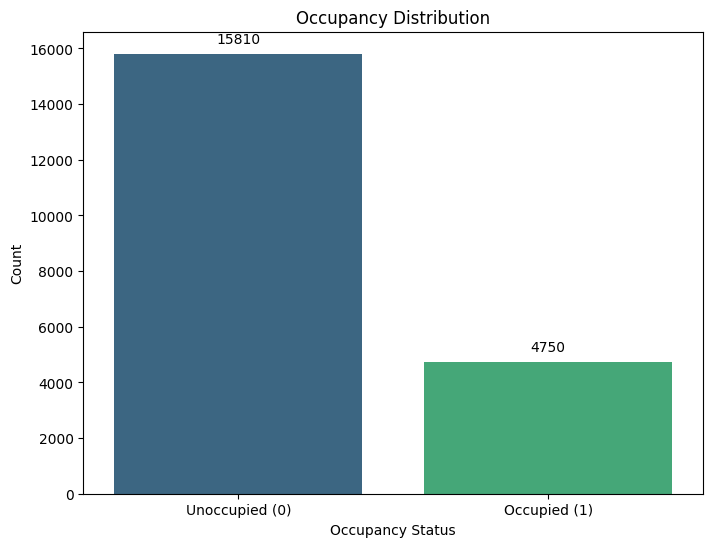

```
Occupancy
0    15810
1     4750
Name: count, dtype: int64
Percentage of Occupied: 23.10%
Percentage of Unoccupied: 76.90%
```

```python
# Plot the distribution of the target variable
plt.figure(figsize=(8, 6))
ax = sns.countplot(x='Occupancy', data=df, palette='viridis')
plt.title('Occupancy Distribution')
plt.xlabel('Occupancy Status')
plt.ylabel('Count')

# Set x-tick labels
ax.set_xticklabels(['Unoccupied (0)', 'Occupied (1)'])

# Add count labels on top of the bars
for p in ax.patches:
    height = p.get_height()
    ax.annotate(f'{int(height)}', xy=(p.get_x() + p.get_width() / 2, height),
                xytext=(0, 5), textcoords='offset points', ha='center', va='bottom')

plt.show()


# Print the counts
occupancy_counts = df['Occupancy'].value_counts()
print(occupancy_counts)
print(f"Percentage of Occupied: {occupancy_counts[1] / len(df) * 100:.2f}%")
print(f"Percentage of Unoccupied: {occupancy_counts[0] / len(df) * 100:.2f}%")
```

## 4. Exploratory Data Analysis (EDA)

### 4.1 Statistical Summary

```python
df.describe()
```

|  | date | Temperature | Humidity | Light | CO2 | HumidityRatio | Occupancy |
| --- | --- | --- | --- | --- | --- | --- | --- |
| count | 20560 | 20560.000000 | 20560.000000 | 20560.000000 | 20560.000000 | 20560.000000 | 20560.000000 |
| mean | 2015-02-10 13:42:06.146984448 | 20.906212 | 27.655925 | 130.756622 | 690.553276 | 0.004228 | 0.231031 |
| min | 2015-02-02 14:19:00 | 19.000000 | 16.745000 | 0.000000 | 412.750000 | 0.002674 | 0.000000 |
| 25% | 2015-02-06 11:05:45 | 20.200000 | 24.500000 | 0.000000 | 460.000000 | 0.003719 | 0.000000 |
| 50% | 2015-02-10 00:45:30 | 20.700000 | 27.290000 | 0.000000 | 565.416667 | 0.004292 | 0.000000 |
| 75% | 2015-02-14 19:39:14.249999872 | 21.525000 | 31.290000 | 301.000000 | 804.666667 | 0.004832 | 0.000000 |
| max | 2015-02-18 09:19:00 | 24.408333 | 39.500000 | 1697.250000 | 2076.500000 | 0.006476 | 1.000000 |
| std | NaN | 1.055315 | 4.982154 | 210.430875 | 311.201281 | 0.000768 | 0.421503 |

### 4.2 Correlation Matrix

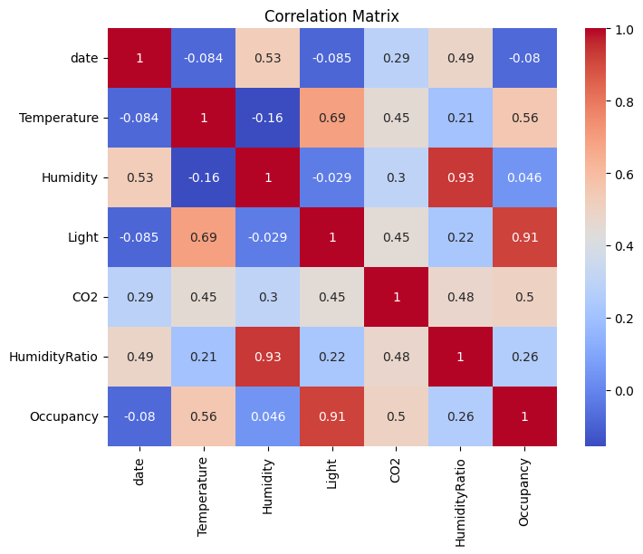

```python
# Compute the correlation matrix
corr_matrix = df.corr()

# Plot the heatmap
plt.figure(figsize=(8, 6))
sns.heatmap(corr_matrix, annot=True, cmap='coolwarm')
plt.title('Correlation Matrix')
plt.show()
```

### 4.3 Pairplot

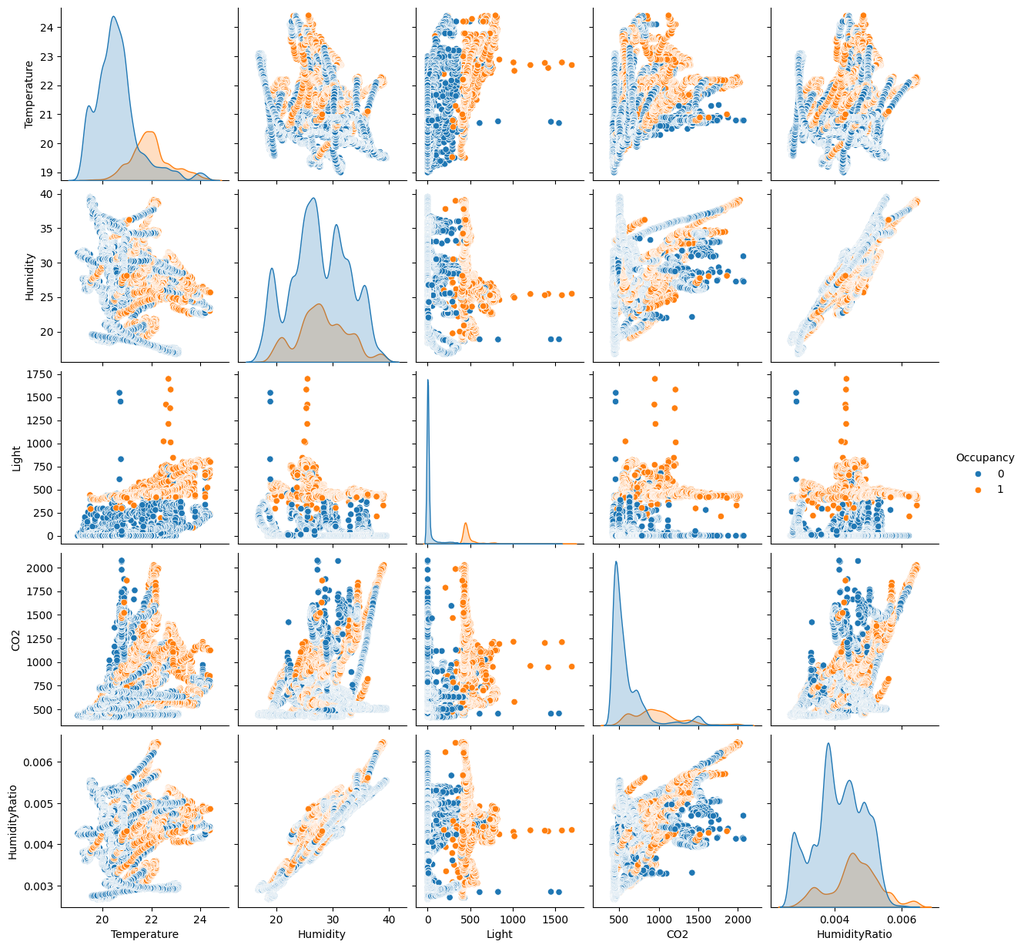

```python
# Plot pairplot
sns.pairplot(df, hue='Occupancy')
plt.show()
```

### 4.4 Histograms

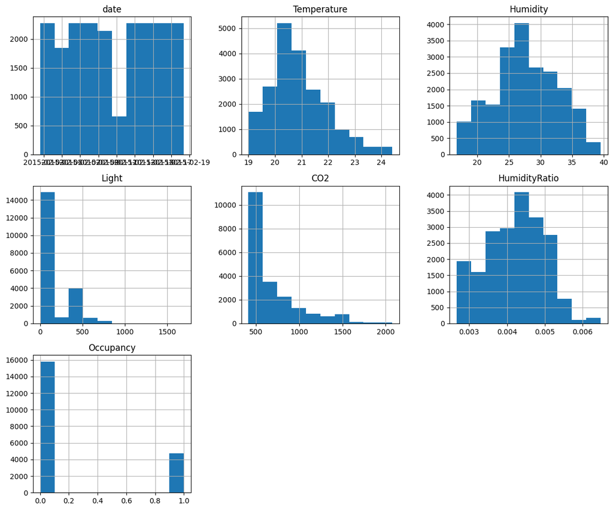

```python
# Plot histograms
df.hist(figsize=(12, 10))
plt.tight_layout()
plt.show()
```

## 5. Data Preprocessing

### 5.1 Feature and Target Separation

```python
# Define features and target variable
features = df[['Temperature', 'Humidity', 'Light', 'CO2', 'HumidityRatio']]
target = df['Occupancy']
```

### 5.2 Data Scaling

We will scale the features for **SVM** and **LSTM** algorithms using **StandardScaler**.

```python
# Initialize the scaler
scaler = StandardScaler()

# Fit and transform the features
scaled_features = scaler.fit_transform(features)

# Convert to DataFrame
scaled_features = pd.DataFrame(scaled_features, columns=features.columns)
```

### 5.3 Final Data Preparation

```python
# Prepare the final dataset
X = scaled_features
y = target
```

## 6. Implementing 10-Fold Cross-Validation

We will use **KFold** with `n_splits=10`, `shuffle=True`, and `random_state=42`.

```python
from sklearn.model_selection import KFold

n_splits = 10
kf = KFold(n_splits=n_splits, shuffle=True, random_state=42)
```

## 7. Defining Metrics Calculation Function

We will define a function to manually calculate performance metrics such as **TPR**, **TNR**, **Precision**, **F1 Score**, **Accuracy**, and others.

```python
def calculate_metrics(y_true, y_pred):
    cm = confusion_matrix(y_true, y_pred)
    if cm.shape == (2, 2):
        TN, FP, FN, TP = cm.ravel()
    else:
        TN = FP = FN = TP = 0
    # Calculations
    P = TP + FN
    N = TN + FP
    TPR = TP / P if P != 0 else 0
    TNR = TN / N if N != 0 else 0
    FPR = FP / N if N != 0 else 0
    FNR = FN / P if P != 0 else 0
    Precision = TP / (TP + FP) if (TP + FP) != 0 else 0
    F1_measure = 2 * TP / (2 * TP + FP + FN) if (2 * TP + FP + FN) != 0 else 0
    Accuracy = (TP + TN) / (P + N) if (P + N) != 0 else 0
    Error_rate = (FP + FN) / (P + N) if (P + N) != 0 else 0
    BACC = (TPR + TNR) / 2
    TSS = TPR - FPR
    HSS = (2 * (TP * TN - FP * FN)) / ((P * (FN + TN)) + ((TP + FP) * (FP + TN))) if ((P * (FN + TN)) + ((TP + FP) * (FP + TN))) != 0 else 0
    return {
        'TP': TP, 'TN': TN, 'FP': FP, 'FN': FN,
        'TPR': TPR, 'TNR': TNR, 'FPR': FPR, 'FNR': FNR,
        'Precision': Precision, 'F1_measure': F1_measure,
        'Accuracy': Accuracy, 'Error_rate': Error_rate,
        'BACC': BACC, 'TSS': TSS, 'HSS': HSS
    }
```

## 8. Modeling and Evaluation

### 8.1 Lists to Store Metrics

```python
rf_metrics_list = []
svm_metrics_list = []
lstm_metrics_list = []
```

### 8.2 Cross-Validation Loop

```python
fold = 1
for train_index, test_index in kf.split(X):
    print(f"Fold {fold}:")

    # Split the data
    X_train, X_test = X.iloc[train_index], X.iloc[test_index]
    y_train, y_test = y.iloc[train_index], y.iloc[test_index]

    ### Random Forest ###
    rf_model = RandomForestClassifier(n_estimators=100, random_state=42)
    rf_model.fit(X_train, y_train)
    rf_pred = rf_model.predict(X_test)
    rf_pred_prob = rf_model.predict_proba(X_test)[:, 1]  # Predicted probabilities
    rf_metrics = calculate_metrics(y_test, rf_pred)
    rf_auc = roc_auc_score(y_test, rf_pred_prob)
    rf_brier = brier_score_loss(y_test, rf_pred_prob)  # Calculate Brier Score
    rf_metrics['AUC'] = rf_auc
    rf_metrics['Brier_score'] = rf_brier  #  Brier Score to metrics
    rf_metrics_list.append(rf_metrics)


    ### Support Vector Machine ###
    svm_model = SVC(kernel='linear', probability=True, random_state=42)
    svm_model.fit(X_train, y_train)
    svm_pred = svm_model.predict(X_test)
    svm_pred_prob = svm_model.predict_proba(X_test)[:, 1]  # Predicted probabilities
    svm_metrics = calculate_metrics(y_test, svm_pred)
    svm_auc = roc_auc_score(y_test, svm_pred_prob)
    svm_brier = brier_score_loss(y_test, svm_pred_prob)  # Calculate Brier Score
    svm_metrics['AUC'] = svm_auc
    svm_metrics['Brier_score'] = svm_brier  #  Brier Score to metrics
    svm_metrics_list.append(svm_metrics)


    ### LSTM ###
    # Reshape data for LSTM
    X_train_lstm = np.array(X_train).reshape((X_train.shape[0], X_train.shape[1], 1))
    X_test_lstm = np.array(X_test).reshape((X_test.shape[0], X_test.shape[1], 1))
    y_train_lstm = np.array(y_train)
    y_test_lstm = np.array(y_test)

    lstm_model = Sequential()
    lstm_model.add(LSTM(64, input_shape=(X_train_lstm.shape[1], 1)))
    lstm_model.add(Dense(1, activation='sigmoid'))
    lstm_model.compile(loss='binary_crossentropy', optimizer='adam', metrics=['accuracy'])
    lstm_model.fit(X_train_lstm, y_train_lstm, epochs=5, batch_size=32, verbose=0)
    lstm_pred_prob = lstm_model.predict(X_test_lstm)
    lstm_pred = (lstm_pred_prob > 0.5).astype(int).reshape(-1)
    lstm_metrics = calculate_metrics(y_test_lstm, lstm_pred)
    lstm_auc = roc_auc_score(y_test_lstm, lstm_pred_prob)
    lstm_brier = brier_score_loss(y_test_lstm, lstm_pred_prob)  # Calculate Brier Score
    lstm_metrics['AUC'] = lstm_auc
    lstm_metrics['Brier_score'] = lstm_brier  #  Brier Score to metrics
    lstm_metrics_list.append(lstm_metrics)


    # Print metrics for the fold
    print(f"Random Forest Accuracy: {rf_metrics['Accuracy']:.2f}, AUC: {rf_metrics['AUC']:.2f}")
    print(f"SVM Accuracy: {svm_metrics['Accuracy']:.2f}, AUC: {svm_metrics['AUC']:.2f}")
    print(f"LSTM Accuracy: {lstm_metrics['Accuracy']:.2f}, AUC: {lstm_metrics['AUC']:.2f}")
    print("------------------------------------------------------")
    fold +=1
```

```
Fold 1:
```

[output not shown]

```
65/65 ━━━━━━━━━━━━━━━━━━━━ 0s 4ms/step
Random Forest Accuracy: 0.99, AUC: 1.00
SVM Accuracy: 0.99, AUC: 1.00
LSTM Accuracy: 0.99, AUC: 1.00
------------------------------------------------------
Fold 2:
65/65 ━━━━━━━━━━━━━━━━━━━━ 0s 4ms/step
Random Forest Accuracy: 1.00, AUC: 1.00
SVM Accuracy: 0.99, AUC: 1.00
LSTM Accuracy: 0.99, AUC: 1.00
------------------------------------------------------
Fold 3:
65/65 ━━━━━━━━━━━━━━━━━━━━ 0s 4ms/step
Random Forest Accuracy: 0.99, AUC: 1.00
SVM Accuracy: 0.99, AUC: 0.99
LSTM Accuracy: 0.99, AUC: 1.00
------------------------------------------------------
Fold 4:
65/65 ━━━━━━━━━━━━━━━━━━━━ 0s 4ms/step
Random Forest Accuracy: 0.99, AUC: 1.00
SVM Accuracy: 0.99, AUC: 0.99
LSTM Accuracy: 0.99, AUC: 1.00
------------------------------------------------------
Fold 5:
65/65 ━━━━━━━━━━━━━━━━━━━━ 0s 4ms/step
Random Forest Accuracy: 1.00, AUC: 1.00
SVM Accuracy: 0.99, AUC: 1.00
LSTM Accuracy: 0.99, AUC: 1.00
------------------------------------------------------
Fold 6:
65/65 ━━━━━━━━━━━━━━━━━━━━ 0s 4ms/step
Random Forest Accuracy: 0.99, AUC: 1.00
SVM Accuracy: 0.99, AUC: 0.99
LSTM Accuracy: 0.99, AUC: 1.00
------------------------------------------------------
Fold 7:
65/65 ━━━━━━━━━━━━━━━━━━━━ 0s 4ms/step
Random Forest Accuracy: 0.99, AUC: 1.00
SVM Accuracy: 0.99, AUC: 0.99
LSTM Accuracy: 0.99, AUC: 1.00
------------------------------------------------------
Fold 8:
65/65 ━━━━━━━━━━━━━━━━━━━━ 0s 4ms/step
Random Forest Accuracy: 0.99, AUC: 1.00
SVM Accuracy: 0.99, AUC: 1.00
LSTM Accuracy: 0.99, AUC: 1.00
------------------------------------------------------
Fold 9:
65/65 ━━━━━━━━━━━━━━━━━━━━ 0s 4ms/step
Random Forest Accuracy: 0.99, AUC: 1.00
SVM Accuracy: 0.98, AUC: 0.99
LSTM Accuracy: 0.98, AUC: 1.00
------------------------------------------------------
Fold 10:
65/65 ━━━━━━━━━━━━━━━━━━━━ 0s 4ms/step
Random Forest Accuracy: 0.99, AUC: 1.00
SVM Accuracy: 0.98, AUC: 0.99
LSTM Accuracy: 0.98, AUC: 0.99
------------------------------------------------------
```

## 9. Results and Analysis

### 9.1 Convert Metrics Lists to DataFrames

```python
# Convert metrics lists to DataFrames
rf_metrics_df = pd.DataFrame(rf_metrics_list)
svm_metrics_df = pd.DataFrame(svm_metrics_list)
lstm_metrics_df = pd.DataFrame(lstm_metrics_list)
```

### 9.2 Average Metrics Over Folds

```python
rf_avg_metrics = rf_metrics_df.mean()
svm_avg_metrics = svm_metrics_df.mean()
lstm_avg_metrics = lstm_metrics_df.mean()
```

### 9.3 Comparison Table

```python
# Comparison Table
comparison_df = pd.DataFrame({
    'Random Forest': rf_avg_metrics,
    'SVM': svm_avg_metrics,
    'LSTM': lstm_avg_metrics
})
comparison_df = comparison_df.round(4)  # Use more decimal places if needed
print(comparison_df)
```

```
             Random Forest        SVM       LSTM
TP                469.8000   473.1000   472.5000
TN               1572.3000  1560.2000  1560.2000
FP                  8.7000    20.8000    20.8000
FN                  5.2000     1.9000     2.5000
TPR                 0.9891     0.9960     0.9947
TNR                 0.9945     0.9868     0.9868
FPR                 0.0055     0.0132     0.0132
FNR                 0.0109     0.0040     0.0053
Precision           0.9818     0.9579     0.9578
F1_measure          0.9854     0.9765     0.9759
Accuracy            0.9932     0.9890     0.9887
Error_rate          0.0068     0.0110     0.0113
BACC                0.9918     0.9914     0.9908
TSS                 0.9836     0.9829     0.9816
HSS                 0.9810     0.9693     0.9685
AUC                 0.9989     0.9944     0.9967
Brier_score         0.0052     0.0107     0.0102
```

### 9.4 ROC Curves

#### 9.4.1 Random Forest ROC Curve

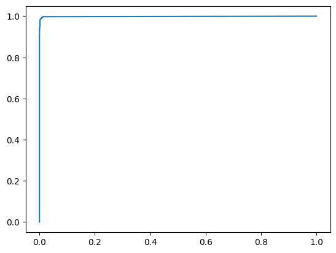

```python
# Plot ROC curve for Random Forest
rf_fpr, rf_tpr, _ = roc_curve(y_test, rf_model.predict_proba(X_test)[:,1])
rf_auc = auc(rf_fpr, rf_tpr)
plt.plot(rf_fpr, rf_tpr, label=f'Random Forest ROC (AUC = {rf_auc:.2f})')
```

#### 9.4.2 SVM ROC Curve

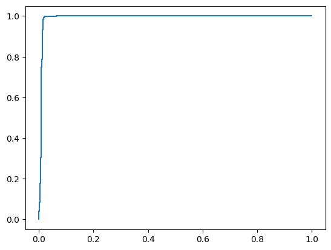

```python
# Plot ROC curve for SVM
svm_fpr, svm_tpr, _ = roc_curve(y_test, svm_model.predict_proba(X_test)[:,1])
svm_auc = auc(svm_fpr, svm_tpr)
plt.plot(svm_fpr, svm_tpr, label=f'SVM ROC (AUC = {svm_auc:.2f})')
```

#### 9.4.3 LSTM ROC Curve

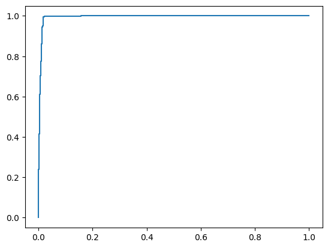

```python
# Plot ROC curve for LSTM
lstm_fpr, lstm_tpr, _ = roc_curve(y_test_lstm, lstm_pred_prob)
lstm_auc = auc(lstm_fpr, lstm_tpr)
plt.plot(lstm_fpr, lstm_tpr, label=f'LSTM ROC (AUC = {lstm_auc:.2f})')
```

#### 9.4.4 Combined ROC Curve

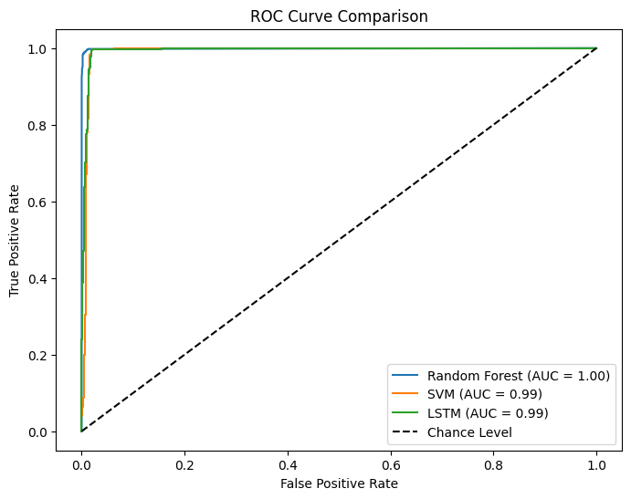

```python
# Combined ROC Curve

plt.figure(figsize=(8, 6))

# Random Forest ROC Curve
rf_fpr, rf_tpr, _ = roc_curve(y_test, rf_model.predict_proba(X_test)[:, 1])
rf_auc = auc(rf_fpr, rf_tpr)
plt.plot(rf_fpr, rf_tpr, label=f'Random Forest (AUC = {rf_auc:.2f})')

# SVM ROC Curve
svm_fpr, svm_tpr, _ = roc_curve(y_test, svm_model.predict_proba(X_test)[:, 1])
svm_auc = auc(svm_fpr, svm_tpr)
plt.plot(svm_fpr, svm_tpr, label=f'SVM (AUC = {svm_auc:.2f})')

# LSTM ROC Curve
lstm_fpr, lstm_tpr, _ = roc_curve(y_test_lstm, lstm_pred_prob)
lstm_auc = auc(lstm_fpr, lstm_tpr)
plt.plot(lstm_fpr, lstm_tpr, label=f'LSTM (AUC = {lstm_auc:.2f})')

# Plot settings
plt.plot([0, 1], [0, 1], 'k--', label='Chance Level')
plt.xlabel('False Positive Rate')
plt.ylabel('True Positive Rate')
plt.title('ROC Curve Comparison')
plt.legend(loc='lower right')
plt.show()
```

## 10. Discussion

### Performance Summary

#### Random Forest:

- **Average Accuracy:** 0.9932
- **Average AUC:** 0.9989
- **Other Metrics:**
  - True Positive Rate (TPR): 0.9891
  - True Negative Rate (TNR): 0.9945
  - Precision: 0.9818
  - F1 Score: 0.9854
  - Error Rate: 0.0068
  - Brier Score: 0.0052

#### Support Vector Machine (SVM):

- **Average Accuracy:** 0.9890
- **Average AUC:** 0.9944
- **Other Metrics:**
  - True Positive Rate (TPR): 0.9960
  - True Negative Rate (TNR): 0.9868
  - Precision: 0.9579
  - F1 Score: 0.9765
  - Error Rate: 0.0110
  - Brier Score: 0.0107

#### Long Short-Term Memory (LSTM):

- **Average Accuracy:** 0.9887
- **Average AUC:** 0.9967
- **Other Metrics:**
  - True Positive Rate (TPR): 0.9947
  - True Negative Rate (TNR): 0.9868
  - Precision: 0.9578
  - F1 Score: 0.9759
  - Error Rate: 0.0113
  - Brier Score: 0.0102

### Observations

#### Exceptional Model Performance:

- All models achieved high classification performance, with accuracies ranging from **98.87%** to **99.32%** and AUCs close to **1.00**.
- High TPR and TNR indicate effective identification of both occupied and unoccupied instances.

#### Random Forest Outperformed Other Models:

- Random Forest achieved the highest accuracy (**99.32%**) and AUC (**99.89%**), outperforming SVM and LSTM.
- It had the lowest error rate and Brier Score, which indicates better calibration and reliability.
- SVM and LSTM had slightly lower accuracies and higher error rates, with SVM showing marginally higher TPR but lower TNR compared to Random Forest.

#### Effectiveness of Features:

- Features such as **Light** and **CO2** are highly predictive of occupancy.
- The environmental sensor data provided sufficient information for accurate predictions.

### Possible Reasons for High Performance

1. **High Predictive Power of Features:**
   - Environmental sensor data captures conditions directly influenced by human presence.
   - For instance, CO2 levels and light intensity increase when a room is occupied.
2. **Data Quality and Consistency:**
   - Clean dataset with no missing values, collected under controlled conditions.
   - Consistent data collection methods enhanced the models' reliability.
3. **Model Capabilities:**
   - **Random Forest:** Handles nonlinear relationships effectively and is robust to overfitting.
   - **SVM:** Finds the optimal separating hyperplane but is sensitive to overlapping classes.
   - **LSTM:** Designed for sequential data; despite limited temporal information, it captured patterns effectively.

### Considerations

1. **Class Imbalance:**
   - Dataset is imbalanced with **76.90% unoccupied** and **23.10% occupied** instances.
   - SVM and LSTM showed slightly lower Precision and higher False Positives, reflecting potential impact of imbalance.
   - Future work could explore techniques like resampling, SMOTE, or adjusting class weights.
2. **Overfitting Potential:**
   - Near-perfect performance suggests potential overfitting.
   - Additional validation on an independent test set is recommended to confirm generalizability.
3. **Model Complexity vs. Performance:**
   - Random Forest is less computationally intensive than LSTM and achieved the highest accuracy.
   - SVM is computationally efficient but slightly underperformed compared to Random Forest.
   - For practical applications, model simplicity and resource efficiency are crucial.

### Implications

- The high accuracy across all models confirms that environmental sensor data is a strong indicator of room occupancy.
- Random Forest is preferred for deployment due to its performance and computational efficiency.
- These findings demonstrate the potential of machine learning models for energy management, security systems, and smart building applications, enhancing efficiency and automation.

## 11. Conclusion

In this project, we successfully implemented and compared three classification algorithms—**Random Forest**, **SVM**, and **LSTM**—on the Occupancy Detection dataset.

### Key Findings

- **Random Forest** outperformed both SVM and LSTM in terms of accuracy, AUC, and calibration (lower Brier Score).
  - Achieved an average accuracy of **99.32%** and an AUC of **99.89%**, which indicates excellent model performance.
- All models demonstrated that environmental sensor data is highly effective for predicting room occupancy.

### Recommendations

#### Model Selection:

- **Random Forest** is recommended due to its superior performance, simplicity, faster training times, and ease of implementation.
- It provides a balance between accuracy and computational efficiency, which makes it suitable for real-time systems.

#### Future Work Could:

1. **Explore Temporal Patterns:**
   - Incorporate temporal features or sequences to enhance model performance, especially for LSTM, which is designed for sequential data.
2. **Address Class Imbalance:**
   - Investigate resampling techniques (e.g., SMOTE) or adjust class weights during model training to improve robustness, particularly for models affected by higher false positives.
3. **Hyperparameter Tuning:**
   - Perform extensive hyperparameter optimization using techniques like Grid Search or Random Search with cross-validation to achieve better performance and reduce overfitting.

#### Deployment Considerations:

- Assess computational resources and latency requirements in practical applications.
- Consider the scalability and maintenance of the model within the system architecture.
- Ensure model interpretability and transparency, particularly in contexts where explainability is crucial.

### Final Thoughts

The findings demonstrate the feasibility and effectiveness of implementing predictive models for room occupancy detection using environmental sensor data. **Random Forest**, in particular, provides an efficient and highly accurate solution that can be integrated into smart building systems to optimize energy usage and enhance security.

#### Benefits of Model Integration:

1. **Energy Efficiency:**
   - Automated control of heating, ventilation, and air conditioning (HVAC) systems based on occupancy.
2. **Security Enhancements:**
   - Improved monitoring and detection of unauthorized occupancy.
3. **Cost Savings:**
   - Reduced energy consumption leads to financial savings and environmental benefits.

## 12. References

1. **Dataset Source:**
   - UCI Machine Learning Repository - [Occupancy Detection Data Set](https://archive.ics.uci.edu/ml/datasets/Occupancy+Detection)
2. **Documentation:**
   - Scikit-learn Documentation: https://scikit-learn.org/stable/
   - Keras Documentation: https://keras.io/

## 13. Appendix

### 13.1 How to Run the Code

```python
#pip install numpy pandas matplotlib seaborn scikit-learn keras tensorflow
```

Place the FinalDataset.xlsx file in the same directory as this notebook.  
Run all the cells sequentially.

### 13.2 Required Packages

- numpy
- pandas
- matplotlib
- seaborn
- scikit-learn
- keras
- tensorflow

### 13.3 Data File

**FinalDataset.xlsx:** Occupancy Detection dataset in Excel format.